# Data Cleaning Lab - Key

# Part 1

```r
library(tidyverse)
# install.packages("naniar")
library(naniar)
```

Read in the CalEnviroScreen data using `read_csv` and the URL https://daseh.org/data/CalEnviroScreen_data.csv

Assign this dataset to an object called “ces”

```r
ces <- read_csv(file = "https://daseh.org/data/CalEnviroScreen_data.csv")
```

### 1.1

Use the `is.na()` and `any()` functions to check if the `Lead` variable in `ces` has any `NA` values. Use the pipe between each step. Hint: You first need to `pull` out the vector version of this variable to use the `is.na()` function.

`Lead`: an estimate of the risk for lead exposure in children living in low-income communities with older housing. A higher number indicates a greater risk.

```
# General format
TIBBLE %>%
  pull(COLUMN) %>%
  is.na() %>%
  any()
```

```r
ces %>%
  pull(Lead) %>%
  is.na() %>%
  any()
```

```
## [1] TRUE
```

### 1.2

Clean rows of ces, so that only rows remain that do NOT have missing values for the `Education` variable, using `drop_na`. Assign this to the object `have_ed_data.`

`Education`: the percentage of the population over 25 with less than a high school education.

```r
have_ed_data <- ces %>% drop_na(Education)
```

### 1.3

Use `naniar` to make a visual of the amount of data missing for each variable of `ces` (use `gg_miss_var()`). Check out more about this package here: https://www.njtierney.com/post/2018/06/12/naniar-on-cran/

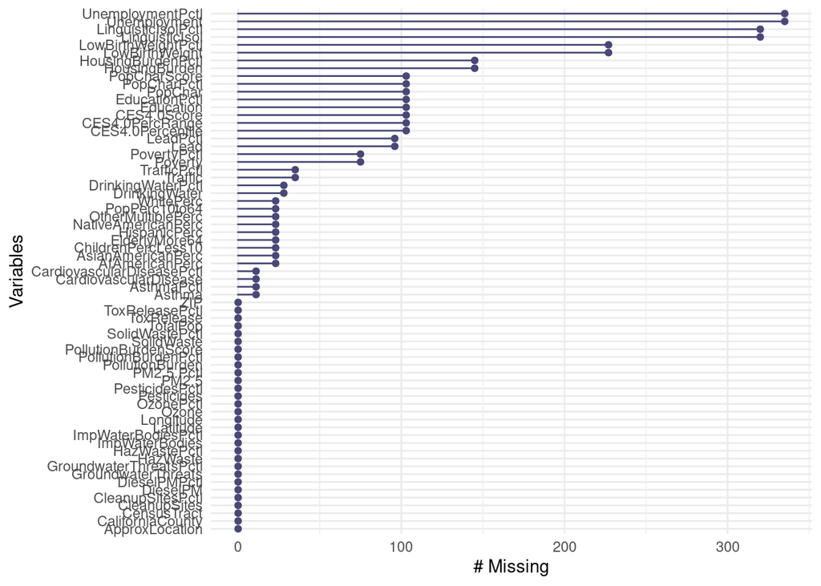

```r
gg_miss_var(ces)
```

# Practice on Your Own!

### P.1

What percentage of the `LinguisticIsol` variable is complete in `ces` ? Hint: use another `naniar` function.

`LinguisticIsol`: the percentage of limited English speaking households within each census tract.

```r
pull(ces, LinguisticIsol) %>% pct_complete() # this
```

```
## [1] 96.01742
```

```r
miss_var_summary(ces) # or this
```

```
## # A tibble: 67 × 3
##    variable           n_miss pct_miss
##    <chr>               <int>    <num>
##  1 Unemployment          335     4.17
##  2 UnemploymentPctl      335     4.17
##  3 LinguisticIsol        320     3.98
##  4 LinguisticIsolPctl    320     3.98
##  5 LowBirthWeight        227     2.83
##  6 LowBirthWeightPctl    227     2.83
##  7 HousingBurden         145     1.80
##  8 HousingBurdenPctl     145     1.80
##  9 CES4.0Score           103     1.28
## 10 CES4.0Percentile      103     1.28
## # ℹ 57 more rows
```

# Part 2

**New Data set**

Let’s imagine we work in a clinic and we are trying to understand more about blood types of patients.

Run the following code to create a dataset that we might collect.

```r
BloodType <- tibble(
  exposure =
    c(
      "Y", "No", "Yes", "y", "no",
      "n", "No", "N", "yes", "Yes",
      "No", "N", NA, "N", "Other"
    ),
  type = c(
    "A.-", "AB.+", "O.-", "O.+", "AB.-",
    "B.+", "B.-", "o.-", "O.+", "A.-",
    "A.+", "O.-", "B.-", "o.+", "AB.-"
  ),
  infection = c(
    "Yes", "No", "Yes", "No", "No",
    "No", "Yes", "No", "Yes", "No",
    "No", "Yes", "Yes", "Yes", "NotSure"
  )
)

BloodType
```

```
## # A tibble: 15 × 3
##    exposure type  infection
##    <chr>    <chr> <chr>
##  1 Y        A.-   Yes
##  2 No       AB.+  No
##  3 Yes      O.-   Yes
##  4 y        O.+   No
##  5 no       AB.-  No
##  6 n        B.+   No
##  7 No       B.-   Yes
##  8 N        o.-   No
##  9 yes      O.+   Yes
## 10 Yes      A.-   No
## 11 No       A.+   No
## 12 N        O.-   Yes
## 13 <NA>     B.-   Yes
## 14 N        o.+   Yes
## 15 Other    AB.-  NotSure
```

There are some issues with this data that we need to figure out!

### 2.1

Determine how many `NA` values there are for `exposure` (assume you know that`N` and `n` is for no).

```r
count(BloodType, exposure) # the simple way
```

```
## # A tibble: 10 × 2
##    exposure     n
##    <chr>    <int>
##  1 N            3
##  2 No           3
##  3 Other        1
##  4 Y            1
##  5 Yes          2
##  6 n            1
##  7 no           1
##  8 y            1
##  9 yes          1
## 10 <NA>         1
```

```r
sum(is.na(pull(BloodType, exposure))) # another way
```

```
## [1] 1
```

```r
BloodType %>% # another way
  pull(exposure) %>%
  is.na() %>%
  sum()
```

```
## [1] 1
```

### 2.2

Recode the `exposure` variable of the `BloodType` data so that it is consistent. Use `case_when()`. Keep “Other” as “Other”. Don’t forget to use quotes!

```
# General format
NEW_TIBBLE <- OLD_TIBBLE %>%
  mutate(NEW_COLUMN = case_when(
    OLD_COLUMN %in% c( ... ) ~ ... ,
    OLD_COLUMN %in% c( ... ) ~ ... ,
    TRUE ~ OLD_COLUMN
  ))
```

```r
BloodType <- BloodType %>%
  mutate(exposure = case_when(
    exposure %in% c("N", "n", "No", "no") ~ "No",
    exposure %in% c("Y", "y", "Yes", "yes") ~ "Yes",
    TRUE ~ exposure # the only other value is an NA so we could include this or we don't need to (it's generally good practice unless we want to create NAs)
  ))

count(BloodType, exposure)
```

```
## # A tibble: 4 × 2
##   exposure     n
##   <chr>    <int>
## 1 No           8
## 2 Other        1
## 3 Yes          5
## 4 <NA>         1
```

### 2.3

Check to see how many values `exposure` has for each category (hint: use `count`). It’s good practice to regularly check your data throughout the data wrangling process.

```r
BloodType %>% count(exposure)
```

```
## # A tibble: 4 × 2
##   exposure     n
##   <chr>    <int>
## 1 No           8
## 2 Other        1
## 3 Yes          5
## 4 <NA>         1
```

### 2.4

Recode the `type` variable of the `BloodType` data to be consistent. Use `case_when()`. Hint: the inconsistency has to do with lower case `o` and capital `O`. Don’t forget to use quotes! **Remember that important extra step that we often do for `case_when()`. Sometimes it matters and sometimes it doesn’t.** Why is that?

```r
BloodType <- BloodType %>%
  mutate(type = case_when(
    type == "o.-" ~ "O.-",
    type == "o.+" ~ "O.+",
    TRUE ~ type))
BloodType
```

```
## # A tibble: 15 × 3
##    exposure type  infection
##    <chr>    <chr> <chr>
##  1 Yes      A.-   Yes
##  2 No       AB.+  No
##  3 Yes      O.-   Yes
##  4 Yes      O.+   No
##  5 No       AB.-  No
##  6 No       B.+   No
##  7 No       B.-   Yes
##  8 No       O.-   No
##  9 Yes      O.+   Yes
## 10 Yes      A.-   No
## 11 No       A.+   No
## 12 No       O.-   Yes
## 13 <NA>     B.-   Yes
## 14 No       O.+   Yes
## 15 Other    AB.-  NotSure
```

### 2.5

Check to see that `type` only has these possible values: “A.-”,“A.+”, “AB.-”, “AB.+”, “B-”,“B+”, “O.-”, “O.+”

```r
BloodType %>% count(type)
```

```
## # A tibble: 8 × 2
##   type      n
##   <chr> <int>
## 1 A.+       1
## 2 A.-       2
## 3 AB.+      1
## 4 AB.-      2
## 5 B.+       1
## 6 B.-       2
## 7 O.+       3
## 8 O.-       3
```

### 2.6

Make a new tibble of `BloodType` called `Bloodtype_split` that splits the `type` variable into two called `blood_type` and `Rhfactor`. Note: periods are special characters that generally are interpreted as wild cards thus we need “\.” instead of simply “.” for the **separating character** to tell R that we want it to be interpreted as a period. Make sure you use quotes around “\.” and the column names like shown below (don’t want backticks).

```
# General format
NEW_TIBBLE <- OLD_TIBBLE %>%
  separate(OLD_COLUMN,
           into = c("NEW_COLUMN1", "NEW_COLUMN2"),
           sep = "SEPARATING_CHARACTER")
```

```r
BloodType_split <- BloodType %>%
  separate(type, into = c("blood_type", "Rhfactor"), sep = "\\.")
```

# Practice on Your Own!

### P.2

How many observations are there for each `Rhfactor` in the data object you just made:

```r
count(BloodType_split, Rhfactor)
```

```
## # A tibble: 2 × 2
##   Rhfactor     n
##   <chr>    <int>
## 1 +            6
## 2 -            9
```

### P.3

Filtering for patients with type O, how many had the infection?

```r
BloodType_split %>%
  filter(blood_type == "O") %>%
  count(infection)
```

```
## # A tibble: 2 × 2
##   infection     n
##   <chr>     <int>
## 1 No            2
## 2 Yes           4
```